# Homework 6

## Problem #1: Testing coin flips (6 pts)

In the six sequences below, only one of them is actually **randomly generated from independent flips of a fair coin**. Use a combination of everything you know (common sense, Monte Carlo, hypothesis testing, etc.) to identify which is actually random and explain your reasoning.

(For full points, conduct a formal test and report a $p$-value for each sequence. You may use a combination of multiple tests to arrive at your answer. If you cannot compute a p-value for each sequence, you can still earn a significant amount of partial credit by carefully explaining your reasoning and response as best as you can.)

My advice is **be creative** with the test statistics you come up with to eliminate each sequence! Think of some way of summarizing a sequence of flips that might be useful for comparing against a simulated sequence of random flips. After you come up with an idea for a statistic, remember to run it on many MC generated completely random flips to produce a distribution under the null, which you can then compare with your data to get a p-value. Also, be careful of now you define “more extreme” than the data.

(2 bonus points available if you can find a single test that is powerful enough to reject all the fake sequences together in one step. Yes, at least one such possible test exists.)

```r
flips1 = "HTHTHTHTHTHTHTHTHTHTHTHTHTHTHTHTHTHTHTHTHTHTHTHTHTHTHTHTHTHT…"

flips2 = "HHHTHTTTHHTHHTHHHTTTTHTHTHHTTHTHHHTHHTHTTTHTHHHTHTTTHTHTHHTH…"

flips3 = "HHTHTHTTTHTHHHTHHTTTHTHHTHTTTHTHTHHTHTHTTHTHHHHHHTTTHTHTHHTH…"

flips4 = "HTHHHHHHHTHTTHHTTHHHTHTHTTTHHTHHHTHHTTHTTTTTTTTTHTHHTTTTTHTH…"

flips5 = "HHHHHHHHHHTTTTTTTTTTHHHHHHHHHHTTTTTTTTTTHHHHHHHHHHTTTTTTTTTT…"

flips6 = "TTHTTTHTTTTTTTHTHTHTHTTHTTHTHHTHHTTTHHTHTTTHTHHTHHHTHTTHHTHH…"

# you can use the function below to split the above sequences in vectors of flips
split = function(str) strsplit(str, split="")[[1]]
split(flips1)
```

```
##   [1] "H" "T" "H" "T" "H" "T" "H" "T" "H" "T" "H" "T" "H" "T" "H" "T" "H" "T"
##  [19] "H" "T" "H" "T" "H" "T" "H" "T" "H" "T" "H" "T" "H" "T" "H" "T" "H" "T"
##  [37] "H" "T" "H" "T" "H" "T" "H" "T" "H" "T" "H" "T" "H" "T" "H" "T" "H" "T"
##  [55] "H" "T" "H" "T" "H" "T" "H" "T" "H" "T" "H" "T" "H" "T" "H" "T" "H" "T"
##  [73] "H" "T" "H" "T" "H" "T" "H" "T" "H" "T" "H" "T" "H" "T" "H" "T" "H" "T"
##  [91] "H" "T" "H" "T" "H" "T" "H" "T" "H" "T" "H" "T" "H" "T" "H" "T" "H" "T"
## [109] "H" "T" "H" "T" "H" "T" "H" "T" "H" "T" "H" "T" "H" "T" "H" "T" "H" "T"
## [127] "H" "T" "H" "T" "H" "T" "H" "T" "H" "T" "H" "T" "H" "T" "H" "T" "H" "T"
## [145] "H" "T" "H" "T" "H" "T" "H" "T" "H" "T" "H" "T" "H" "T" "H" "T" "H" "T"
## [163] "H" "T" "H" "T" "H" "T" "H" "T" "H" "T" "H" "T" "H" "T" "H" "T" "H" "T"
## [181] "H" "T" "H" "T" "H" "T" "H" "T" "H" "T" "H" "T" "H" "T" "H" "T" "H" "T"
## [199] "H" "T"
```

> Before I start with the hypothesis testing, I can confidently say that flips1 and flips5 are not generated by a fair coin, because those series of H an T are extremely unusual.

```r
# Function to find the longest run of heads ("H") in a vector of coin flips
longest_heads_run <- function(flips) {
  max_run <- 0   # Variable to store the maximum run of heads
  current_run <- 0  # Variable to count the current run of heads

  for (flip in flips) {
    if (flip == "H") {
      current_run <- current_run + 1  # Increment the current run of heads
    } else {
      if (current_run > max_run) {
        max_run <- current_run  # Update max_run if current_run is greater
      }
      current_run <- 0  # Reset the current run if the flip is not heads
    }
  }

  # Final check in case the longest run is at the end of the sequence
  if (current_run > max_run) {
    max_run <- current_run
  }

  return(max_run)
}

# Example usage
longest_heads_run(split(flips1))
```

```
## [1] 1
```

```r
longest_heads_run(split(flips2))
```

```
## [1] 3
```

```r
longest_heads_run(split(flips3))
```

```
## [1] 6
```

```r
longest_heads_run(split(flips4))
```

```
## [1] 7
```

```r
longest_heads_run(split(flips5))
```

```
## [1] 10
```

```r
longest_heads_run(split(flips6))
```

```
## [1] 3
```

```r
# Function to simulate fair coin flips and find the longest run of heads
simulate_coin_flips <- function(n_flips) {
  flips <- sample(c("H", "T"), size = n_flips, replace = TRUE)  # Simulate fair coin flips
  return(longest_heads_run(flips))  # Return the longest run of heads
}

# Number of flips in each sequence
n_flips <- 200  # Adjust this to the actual length of your flip sequences

# Monte Carlo simulation to find the average longest run of heads over 10,000 trials
set.seed(123)
n_trials <- 10000
longest_runs <- numeric(n_trials)

for (i in 1:n_trials) {
  longest_runs[i] <- simulate_coin_flips(n_flips)
}

# Calculate the average longest run of heads from the Monte Carlo simulation
average_longest_run <- mean(longest_runs)
print(paste("Average longest run of heads from Monte Carlo simulation (using a fair coin):", average_longest_run))
```

```
## [1] "Average longest run of heads from Monte Carlo simulation (using a fair coin): 7.023"
```

```r
# Compare with the longest run of heads from each provided sequence
flips_list <- list(flips1, flips2, flips3, flips4, flips5, flips6)
results <- sapply(flips_list, function(flip_sequence) {
  flips_vector <- split(flip_sequence)
  longest_heads <- longest_heads_run(flips_vector)
  return(longest_heads)
})

# Combine the results
comparison <- data.frame(Sequence = paste0("Flips", 1:6),
                         LongestRun = results,
                         Difference = results - average_longest_run)

# Print comparison results
print(comparison)
```

```
##   Sequence LongestRun Difference
## 1   Flips1          1     -6.023
## 2   Flips2          3     -4.023
## 3   Flips3          6     -1.023
## 4   Flips4          7     -0.023
## 5   Flips5         10      2.977
## 6   Flips6          3     -4.023
```

> Null Hypothesis (H0): The observed sequence of flips is generated from a fair coin (i.e., the longest run of heads observed is consistent with the expected longest run from random flips).

> Alternative Hypothesis (H1): The observed sequence of flips is not generated from a fair coin (i.e., the longest run of heads observed is significantly greater than what would be expected from random flips).

```r
# Calculate p-values for each sequence
p_values <- sapply(results, function(longest_run) {
  # P-value is the proportion of simulated runs that are less than or equal to the longest run
  mean(longest_runs <= longest_run)
  #2 * min(mean(longest_runs >= longest_run), mean(longest_runs <= longest_run))      # if we want 2 sided test
})

# Combine the results into a data frame
comparison <- data.frame(Sequence = paste0("Flips", 1:6),
                         LongestRun = results,
                         PValue = p_values)

print(comparison)
```

```
##   Sequence LongestRun PValue
## 1   Flips1          1 0.0000
## 2   Flips2          3 0.0008
## 3   Flips3          6 0.4506
## 4   Flips4          7 0.6712
## 5   Flips5         10 0.9494
## 6   Flips6          3 0.0008
```

> Since I have previously stated that flip5 is not generated by a fair coin, the closest one after that is flip4.

> The solution above checks only for Heads, so here is another solution that checks for any (heads or tails) longest sequence.

```r
set.seed(123)
flips1 = "HTHTHTHTHTHTHTHTHTHTHTHTHTHTHTHTHTHTHTHTHTHTHTHTHTHTHTHTHTHT…"

flips2 = "HHHTHTTTHHTHHTHHHTTTTHTHTHHTTHTHHHTHHTHTTTHTHHHTHTTTHTHTHHTH…"

flips3 = "HHTHTHTTTHTHHHTHHTTTHTHHTHTTTHTHTHHTHTHTTHTHHHHHHTTTHTHTHHTH…"

flips4 = "HTHHHHHHHTHTTHHTTHHHTHTHTTTHHTHHHTHHTTHTTTTTTTTTHTHHTTTTTHTH…"

flips5 = "HHHHHHHHHHTTTTTTTTTTHHHHHHHHHHTTTTTTTTTTHHHHHHHHHHTTTTTTTTTT…"

flips6 = "TTHTTTHTTTTTTTHTHTHTHTTHTTHTHHTHHTTTHHTHTTTHTHHTHHHTHTTHHTHH…"

# you can use the function below to split the above sequences in vectors of flips
split = function(str) strsplit(str, split="")[[1]]
split(flips1)
```

```
##   [1] "H" "T" "H" "T" "H" "T" "H" "T" "H" "T" "H" "T" "H" "T" "H" "T" "H" "T"
##  [19] "H" "T" "H" "T" "H" "T" "H" "T" "H" "T" "H" "T" "H" "T" "H" "T" "H" "T"
##  [37] "H" "T" "H" "T" "H" "T" "H" "T" "H" "T" "H" "T" "H" "T" "H" "T" "H" "T"
##  [55] "H" "T" "H" "T" "H" "T" "H" "T" "H" "T" "H" "T" "H" "T" "H" "T" "H" "T"
##  [73] "H" "T" "H" "T" "H" "T" "H" "T" "H" "T" "H" "T" "H" "T" "H" "T" "H" "T"
##  [91] "H" "T" "H" "T" "H" "T" "H" "T" "H" "T" "H" "T" "H" "T" "H" "T" "H" "T"
## [109] "H" "T" "H" "T" "H" "T" "H" "T" "H" "T" "H" "T" "H" "T" "H" "T" "H" "T"
## [127] "H" "T" "H" "T" "H" "T" "H" "T" "H" "T" "H" "T" "H" "T" "H" "T" "H" "T"
## [145] "H" "T" "H" "T" "H" "T" "H" "T" "H" "T" "H" "T" "H" "T" "H" "T" "H" "T"
## [163] "H" "T" "H" "T" "H" "T" "H" "T" "H" "T" "H" "T" "H" "T" "H" "T" "H" "T"
## [181] "H" "T" "H" "T" "H" "T" "H" "T" "H" "T" "H" "T" "H" "T" "H" "T" "H" "T"
## [199] "H" "T"
```

```r
# Function to calculate autocorrelation for a given lag
autocorrelation <- function(sequence, lag) {
  n <- length(sequence)
  sequence_lagged <- sequence[(lag + 1):n]
  sequence_original <- sequence[1:(n - lag)]

  # Compute correlation between original and lagged sequence
  return(cor(sequence_original, sequence_lagged))
}

# Function to calculate the maximum streak length
max_streak_length <- function(sequence) {
  max_streak <- 0
  current_streak <- 1

  for (i in 2:length(sequence)) {
    if (sequence[i] == sequence[i - 1]) {
      current_streak <- current_streak + 1
    } else {
      max_streak <- max(max_streak, current_streak)
      current_streak <- 1
    }
  }
  max_streak <- max(max_streak, current_streak) # Handle case when last streak is the longest
  return(max_streak)
}

# Convert coin flips sequences to 0s and 1s (H = 1, T = 0)
convert_to_numeric <- function(sequence) {
  return(as.numeric(sequence == 'H'))
}

flips1 <- unlist(strsplit("HTHTHTHTHTHTHTHTHTHTHTHTHTHTHTHTHTHTHTHTHTHTHTHTHTHTHTHTHTHT…", ""))
flips2 <- unlist(strsplit("HHHTHTTTHHTHHTHHHTTTTHTHTHHTTHTHHHTHHTHTTTHTHHHTHTTTHTHTHHTH…", ""))
flips3 <- unlist(strsplit("HHTHTHTTTHTHHHTHHTTTHTHHTHTTTHTHTHHTHTHTTHTHHHHHHTTTHTHTHHTH…", ""))
flips4<- unlist(strsplit("HTHHHHHHHTHTTHHTTHHHTHTHTTTHHTHHHTHHTTHTTTTTTTTTHTHHTTTTTHTH…", ""))
flips5<- unlist(strsplit("HHHHHHHHHHTTTTTTTTTTHHHHHHHHHHTTTTTTTTTTHHHHHHHHHHTTTTTTTTTT…", ""))
flips6<- unlist(strsplit("TTHTTTHTTTTTTTHTHTHTHTTHTTHTHHTHHTTTHHTHTTTHTHHTHHHTHTTHHTHH…", ""))

# Convert to numeric
flips1_num <- convert_to_numeric(flips1)
flips2_num <- convert_to_numeric(flips2)
flips3_num <- convert_to_numeric(flips3)
flips4_num <- convert_to_numeric(flips4)
flips5_num <- convert_to_numeric(flips5)
flips6_num <- convert_to_numeric(flips6)

max_streak_flips1 <- max_streak_length(flips1_num)
max_streak_flips2 <- max_streak_length(flips2_num)
max_streak_flips3 <- max_streak_length(flips3_num)
max_streak_flips4 <- max_streak_length(flips4_num)
max_streak_flips5 <- max_streak_length(flips5_num)
max_streak_flips6 <- max_streak_length(flips6_num)

cat("Flips1 Max Streak Length:", max_streak_flips1, "\n")
```

```
## Flips1 Max Streak Length: 1
```

```r
cat("Flips2 Max Streak Length:", max_streak_flips2, "\n")
```

```
## Flips2 Max Streak Length: 4
```

```r
cat("Flips3 Max Streak Length:", max_streak_flips3, "\n")
```

```
## Flips3 Max Streak Length: 6
```

```r
cat("Flips4 Max Streak Length:", max_streak_flips4, "\n")
```

```
## Flips4 Max Streak Length: 9
```

```r
cat("Flips5 Max Streak Length:", max_streak_flips5, "\n")
```

```
## Flips5 Max Streak Length: 10
```

```r
cat("Flips6 Max Streak Length:", max_streak_flips6, "\n")
```

```
## Flips6 Max Streak Length: 12
```

```r
# Function to simulate coin flips and find max streak length
simulate_max_streak <- function(n_flips) {
  sequence <- sample(c(0, 1), n_flips, replace = TRUE)  # Random sequence (0 = T, 1 = H)
  max_streak_length(sequence)
}
simulate_max_streak(200)
```

```
## [1] 7
```

```r
# Simulate max streak lengths for many random sequences

n_simulations <- 10000
n_flips <- 200
simulated_streaks <- replicate(n_simulations, simulate_max_streak(n_flips))

# Compare observed max streaks with simulated distribution
observed_streaks <- c(1, 4, 6, 9, 10, 12)

# Calculate the proportion of simulated streaks that are longer than or equal to each observed streak
p_values <- sapply(observed_streaks, function(obs) mean(simulated_streaks >= obs))

cat("P-values for each observed streak length:", p_values, "\n")
```

```
## P-values for each observed streak length: 1 1 0.9662 0.3206 0.1718 0.0482
```

> Another method I would use is Autocorrelation.

```r
flips1 = "HTHTHTHTHTHTHTHTHTHTHTHTHTHTHTHTHTHTHTHTHTHTHTHTHTHTHTHTHTHT…"

flips2 = "HHHTHTTTHHTHHTHHHTTTTHTHTHHTTHTHHHTHHTHTTTHTHHHTHTTTHTHTHHTH…"

flips3 = "HHTHTHTTTHTHHHTHHTTTHTHHTHTTTHTHTHHTHTHTTHTHHHHHHTTTHTHTHHTH…"

flips4 = "HTHHHHHHHTHTTHHTTHHHTHTHTTTHHTHHHTHHTTHTTTTTTTTTHTHHTTTTTHTH…"

flips5 = "HHHHHHHHHHTTTTTTTTTTHHHHHHHHHHTTTTTTTTTTHHHHHHHHHHTTTTTTTTTT…"

flips6 = "TTHTTTHTTTTTTTHTHTHTHTTHTTHTHHTHHTTTHHTHTTTHTHHTHHHTHTTHHTHH…"

 sequence_bin1 <- as.numeric(unlist(strsplit(flips1, "")) == "H")
 sequence_bin2 <- as.numeric(unlist(strsplit(flips2, "")) == "H")
 sequence_bin3 <- as.numeric(unlist(strsplit(flips3, "")) == "H")
 sequence_bin4 <- as.numeric(unlist(strsplit(flips4, "")) == "H")
 sequence_bin5 <- as.numeric(unlist(strsplit(flips5, "")) == "H")
 sequence_bin6 <- as.numeric(unlist(strsplit(flips6, "")) == "H")

# Function to calculate autocorrelation for a given lag
compute_autocorrelation <- function(sequence, lag) {
  n <- length(sequence)
  if (lag >= n) return(NA)

  seq1 <- sequence[1:(n-lag)]
  seq2 <- sequence[(lag+1):n]

  return(cor(seq1, seq2))
}

# Generate a random coin flip sequence (H = 1, T = 0)
generate_random_sequence <- function(n) {
  sample(c(0, 1), size = n, replace = TRUE)
}

# Function to perform the Monte Carlo test with autocorrelation
autocorrelation_test <- function(observed_seq, n_sim = 1000, max_lag = 5) {
  n <- length(observed_seq)

  # Compute autocorrelation for observed sequence
  observed_autocorrs <- sapply(1:max_lag, function(lag) compute_autocorrelation(observed_seq, lag))

  # Monte Carlo simulation
  sim_autocorrs <- matrix(NA, nrow = n_sim, ncol = max_lag)

  for (i in 1:n_sim) {
    random_seq <- generate_random_sequence(n)
    sim_autocorrs[i, ] <- sapply(1:max_lag, function(lag) compute_autocorrelation(random_seq, lag))
  }

  # Calculate p-values for each lag
  p_values <- sapply(1:max_lag, function(lag) {
    mean(abs(sim_autocorrs[, lag]) >= abs(observed_autocorrs[lag]))
  })

  return(list(observed_autocorrs = observed_autocorrs, sim_autocorrs = sim_autocorrs, p_values = p_values))
}

# Run autocorrelation test
test_result_flips1 <- autocorrelation_test(sequence_bin1, n_sim = 10000, max_lag = 5)
test_result_flips2 <- autocorrelation_test(sequence_bin2, n_sim = 10000, max_lag = 5)
test_result_flips3 <- autocorrelation_test(sequence_bin3, n_sim = 10000, max_lag = 5)
test_result_flips4 <- autocorrelation_test(sequence_bin4, n_sim = 10000, max_lag = 5)
test_result_flips5 <- autocorrelation_test(sequence_bin5, n_sim = 10000, max_lag = 5)
test_result_flips6 <- autocorrelation_test(sequence_bin6, n_sim = 10000, max_lag = 5)

# Print results
print("Autocorrelation Test for flips1:")
```

```
## [1] "Autocorrelation Test for flips1:"
```

```r
print(test_result_flips1$p_values)
```

```
## [1] 0 0 0 0 0
```

```r
print("Autocorrelation Test for flips2:")
```

```
## [1] "Autocorrelation Test for flips2:"
```

```r
print(test_result_flips2$p_values)
```

```
## [1] 0.0000 0.0335 0.9324 0.2498 0.1023
```

```r
print("Autocorrelation Test for flips3:")
```

```
## [1] "Autocorrelation Test for flips3:"
```

```r
print(test_result_flips3$p_values)
```

```
## [1] 0.0007 0.0019 0.1012 0.6732 0.0011
```

```r
print("Autocorrelation Test for flips4:")
```

```
## [1] "Autocorrelation Test for flips4:"
```

```r
print(test_result_flips4$p_values)
```

```
## [1] 0.5217 0.9902 0.4489 0.5896 0.0546
```

```r
print("Autocorrelation Test for flips5:")
```

```
## [1] "Autocorrelation Test for flips5:"
```

```r
print(test_result_flips5$p_values)
```

```
## [1] 0.0000 0.0000 0.0000 0.0019 0.7064
```

```r
print("Autocorrelation Test for flips6:")
```

```
## [1] "Autocorrelation Test for flips6:"
```

```r
print(test_result_flips6$p_values)
```

```
## [1] 0.1584 0.9117 0.4931 0.4059 0.2933
```

> Here we can conclude that for different lags, flips4 and flips6 are the most consistent, with probabilities higher thatn 0.05.

> The final conclusion is: flips4 is the fair coin. Flips4 is randomly generated from independent flips of a fair coin.

## Problem #2: Finding the Trick Coin (6 pts; 2pts each)

I have two coins in my pocket - a trick coin with two heads and a fair coin with one head and one tail(s?). We’ll play a game. I will grab one coin at random, and flip it $N$ times. After that you will have to decide if it is the fair coin or the trick coin. The null hypothesis is that it is the fair coin.

**Decision Rule 1**: If after $N$ flips there are no tails, then you decide it is the trick coin. If there is at least 1 tail then you know it is the fair coin.

1. Using “Decision Rule 1”, what is the lowest number of flips $N$ would you need in order to have a significance level less than 5% for this test?

> The probability of getting no tails in N flips of a fair coin, which has a probability of getting heads of 0.5, is given by P(no tails) equals 0.5 raised to the power of N. To find N such that 0.5 raised to the power of N is less than 0.05, we need to solve this inequality.

> P(no tails) = 0.5^N to find such that 0.5^N < 0.05

> The minimum number of flips we need is 5, after that we would be able to conclude whther the coin was fair or trick.
2. Using $N$ from part a, what is the power of the test?

> To calculate the power of the test with N equals 5, we use the formula:

> Power = 1 - P(no tails), which is equal to 1 - 0.5 ^ N.

> For N = 5, we first calculate P(no tails):

> P(no tails) = 0.5 ^ 5, which equals 1 / 32, approximately 0.03125.

> Next, we calculate the power:

> Power = 1 - P(no tails) = 1 - 0.5 ^ 5, which equals 1 - 0.03125, resulting in approximately 0.96875.

> Thus, the power of the test when N equals 5 is approximately 0.96875, meaning there is a 96.875% chance of correctly rejecting the null hypothesis if the chosen coin is the fair coin.
3. Suppose $N=4$ is decided. How can you modify the decision process to have a significance level of exactly 5%? Does this change the power of the test?

> The current decision rule is to reject the null hypothesis (the coin is fair) if there are 0 tails in 4 flips. This gives a significance level of P(0 tails) equals 0.5 raised to the power of 4, which equals 0.0625.

> To achieve exactly a 5% significance level, we can modify the rule to reject the null hypothesis if there are 0 or 1 tails. This gives us the probability of 0 tails, which remains 0.0625, and the probability of 1 tail can be calculated as follows: P(1 tail) equals 4 choose 1 times 0.5 raised to the power of 1 times 0.5 raised to the power of 3, which results in 4 times 0.5 times 0.125, equaling 0.25.

> The total significance level becomes alpha equals 0.0625 plus 0.25, which equals 0.3125, indicating it is too high.

> For the final adjustment to lower the significance level to exactly 5%, we may need to adjust the conditions further or limit the number of heads allowed to achieve the exact probability of rejecting the null hypothesis.

> Regarding the power of the test with the modified rule (rejecting for 0 or 1 tails), if the trick coin is chosen, you will always see 0 tails, so the power remains equal to 1.
4. Extra Credit (2 points): Suppose if you guess correct you win $100 (and if you’re wrong you get nothing), but each flip of the coin costs $10. What strategy would you use to maximize your expected profit from this game?

> In case we substract the 10$ AFTER we multiply with the probability:

> For N=1: Probability = 0.50 1-1/2 E(1)=0.50*100-10=40

> For N=2: Probability = 0.75 1-1/2^2 E(2)=0.75*100-20=55

> For N=3: Probability = 0.875 1-1/2^3 E(3)=0.875*100-30=57.50

> For N=4: Probability = 0.9375 1-1/2^4 E(4)=0.9375*100-40=53.75

> In case we substract the 10$ BEFORE we multiply with the probability:

> Initial Decision Rule (0 flips): Expected value without any flips: You have a 50% chance of either coin being selected randomly. Expected value = 50% of $100 + 50% of $0 = $50. You could guess without flipping, but this would only give an expected profit of $50.

> Decision After 1 Flip: If you flip once, the coin will either show heads or tails. If you see tails, you know it’s the fair coin (since the trick coin never shows tails), so you guess fair and win $100. If you see heads, the coin could still be either the trick or fair coin, so you remain uncertain. Cost for 1 flip = $10. Expected profit after 1 flip: Probability of seeing tails (knowing it’s the fair coin): 50%. If tails: profit = $100 - $10 (cost of flip) = $90. If heads: you remain uncertain but can still guess randomly (50% chance of being right). Expected profit for heads: 50% of ($100 - $10) = $45. Overall expected profit after 1 flip: 50% of $90 + 50% of $45 = $67.5.

> Decision After 2 Flips: If you flip twice: If you see at least one tail, you know the coin is fair and win $100. If both flips are heads, you become more confident it’s the trick coin, but the fair coin is still possible. Cost for 2 flips = $20. Expected profit after 2 flips: Probability of seeing at least one tail (knowing it’s the fair coin) is 75%. If at least one tail: profit = $100 - $20 (cost) = $80. If both flips are heads, you remain uncertain, but you can guess randomly. Expected profit for both heads: 50% of ($100 - $20) = $40. Overall expected profit after 2 flips: 75% of $80 + 25% of $40 = $70.

## Problem #3: Testing the maximum of a uniform distribution (8 pts; 2 pts each)

We sample $X_1, X_x,\ldots,X_n \overset{\text{iid}}\sim\text{Uniform}(0,m)$ where $m$ is an unknown maximum. Sleazy Jim tells you that $m=1$ but you’re not so sure. The 50 values sampled are in the following data file:

```r
X <- read.csv("uniform_sample.csv")$x
head(X)
```

```
## [1] 0.3432461 0.8453318 0.6849625 0.1693051 0.2002104 0.3569238
```

1. Write out in formal notation the null and alternative hypotheses.

> H0: m = 1 (uniform distribution over [0,1])

> H1: m != 1 (actual m is not 1)
2. Come up with a test statistic and measure your sampled data. Is this a one-sided test or two-sided test?

> Test statistic T=Xmax where Xmax=max(x1,…..xn) = 0.9443383

> It is two-sided test because we want to test friend’s claim that m=1 and actually do not know direction of the claim, is m>1 or m<1.
3. Simulate a distribution for the test statistic under the null hypothesis of size at least 1000. Display a histogram of your test statistic distribution.

```r
n <- 50  # Sample size
M <- 1000  # Number of simulations

# Simulate the maximum values of uniform distribution over [0,1]
sim_max <- replicate(M, max(runif(n, 0, 1)))
#sim_max
mean(sim_max) # mean of the maxes of the simulated sequences
```

```
## [1] 0.9798257
```

```r
# Observed max from the sample
obs_max<- max(X)
obs_max
```

```
## [1] 0.9443383
```

```r
# Calculate the p-value simulated max greater than observed
p_value <- mean(sim_max >= obs_max)
p_value
```

```
## [1] 0.932
```

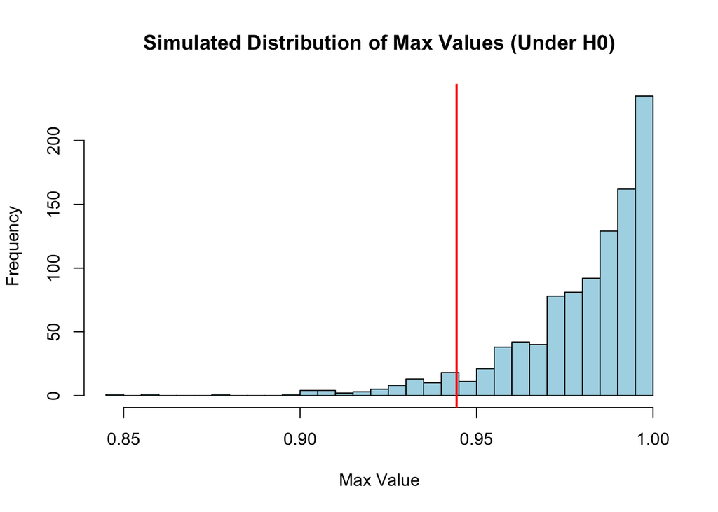

```r
# Plot the histogram
hist(sim_max, breaks = 30, main = "Simulated Distribution of Max Values (Under H0)",
     xlab = "Max Value", col = "lightblue")

# Add a red line at the observed max value
abline(v = obs_max, col = "red", lwd = 2)
```

4. Calculate the $p$-value for this data and make a conclusion.

## Problem #4: Blurtle (10 pts; 2 pt each)

Have you been playing the hot new game Blurtle? It’s a (fictional) word game you can play daily - you have to guess a 5 letter word and you only have 6 attempts. I’ve been playing for the past 100 days and I’ve been tracking my number of guesses. I’m trying to figure out whether I have been getting better or not.

The file `blurtle.csv` contains 100 rows of data, giving the number of tries to guess the word. If it took 7 guesses that actually means I failed (you don’t actually get a 7th guess).

Your task is to perform a permutation test on the data to determine if there is statistical evidence of a true improvement trend.

1. State the null and alternative hypotheses

> H0: There is no change in the trend in the number of tries.

> H1: There is change in the trend in the number of tries
2. Determine a test statistic that identifies a trend in the number of tries. There are many good ones you could use - be creative.

> Spearman rank correlation coefficient between day and number of tries can be used. This statistic will capture the monotonic trend, indicating if there’s a general improvement or deterioration over time.
3. Decide whether the test will be a one or two-tailed test

> Two-tailed test is used because we are looking for either improvement or deterioration - lower or greater number of guesses.
4. Simulate a distribution of test statistics under the null hypothesis
5. Calculate the test statistic on the observed data, calculate the $p$-value and state your conclusions.

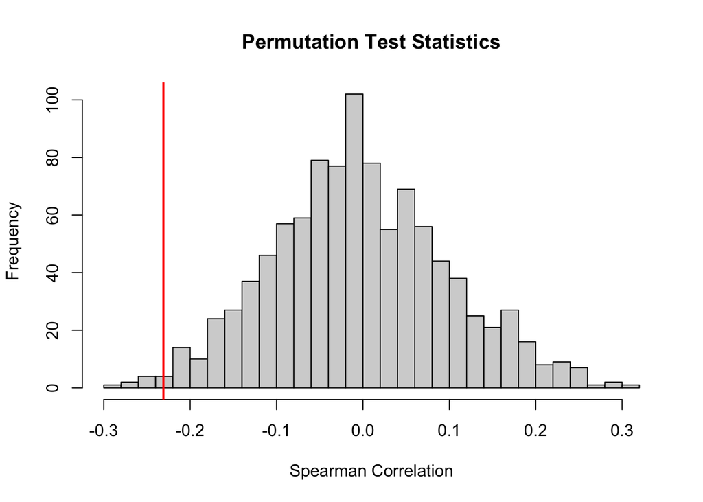

```r
blurtle <- read.csv("blurtle.csv")

#blurtle
#blurtle$tries
#mean(blurtle$tries)
#var(blurtle$tries)

# Compute observed test statistic
observed_stat <- cor(blurtle$day, blurtle$tries, method = "spearman")

# Permutation test function
perm_test <- function(data, n_perm = 1000) {
  perm_stats <- numeric(n_perm)

  for (i in 1:n_perm) {
    perm_data <- data
    perm_data$tries <- sample(perm_data$tries)
    perm_stats[i] <- cor(perm_data$day, perm_data$tries, method = "spearman")
  }

  return(perm_stats)
}

set.seed(123)
perm_stats <- perm_test(blurtle)

# Calculate p-value
p_value <- (sum(abs(perm_stats) >= abs(observed_stat)) + 1) / (length(perm_stats) + 1)

# Plot distribution of permutation test statistics
hist(perm_stats, main = "Permutation Test Statistics", xlab = "Spearman Correlation", breaks = 30)
abline(v = observed_stat, col = "red", lwd = 2)
```

```r
print(paste("Observed test statistic: ", observed_stat))
```

```
## [1] "Observed test statistic:  -0.230958875668475"
```

```r
print(paste("P-value: ", p_value))
```

```
## [1] "P-value:  0.023976023976024"
```

> We conclude that there is enough evidence to reject the H0 hypothesis. Test statistic has negative value meaning that there is enough evidence that number of guesses by days is lowering.

> As a check we can do a regression on the data on a scatter plot and follow the line. If it has negative slope, that means that the number of tres is decreasing over time and we are making progress - numebr of guesses is lowering.

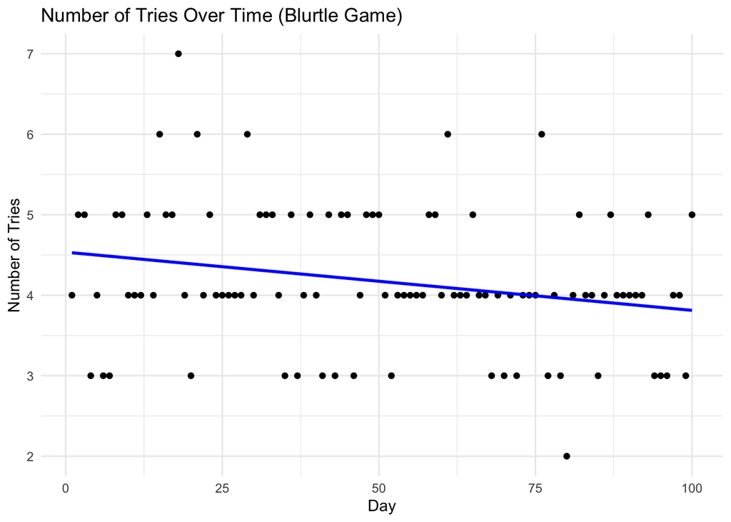

```r
# Load necessary library
library(ggplot2)

# Create scatter plot with regression line
ggplot(blurtle, aes(x = day, y = tries)) +
  geom_point() +  # Scatter plot points
  geom_smooth(method = "lm", color = "blue", se = FALSE) +  # Linear regression line
  labs(title = "Number of Tries Over Time (Blurtle Game)", x = "Day", y = "Number of Tries") +
  theme_minimal()
```